# Linear Regression

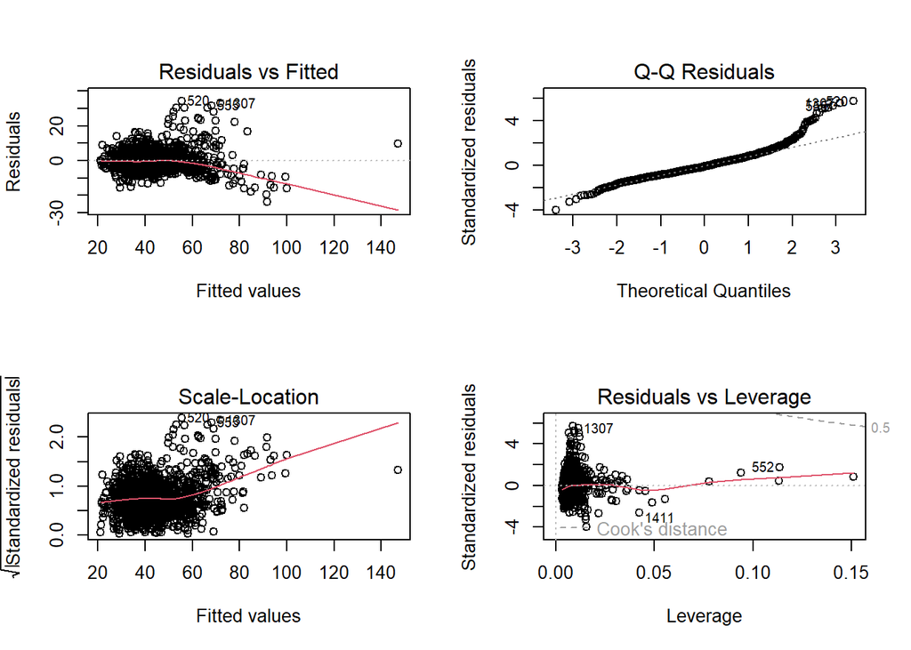

```r
par(mfrow=c(2,2))
plot(fit_drop)
```

Dropping the extreme cook distant points does not improve the model.

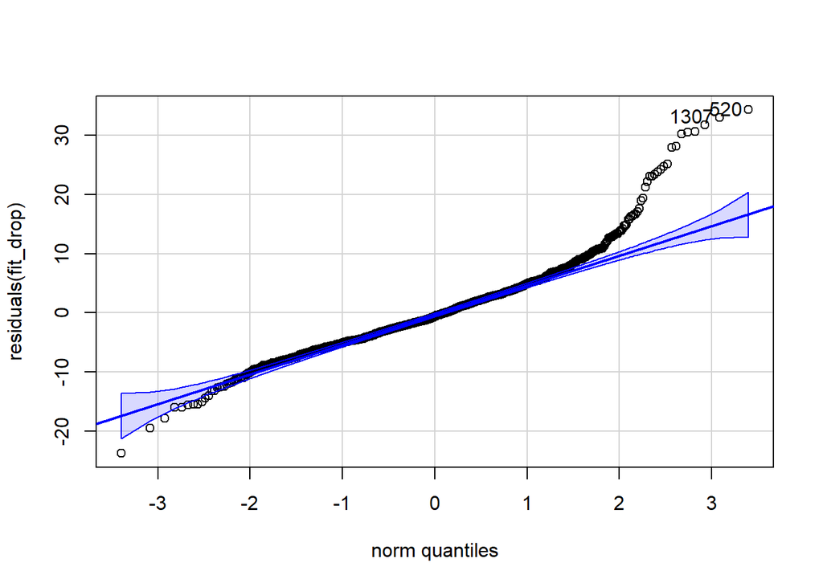

```
##  520 1307
##  519 1304
```

```r
qqPlot(residuals(fit_drop))
```

```r
pred_fit_drop <- predict(fit_drop, newdata = test_full)

rmse_fit_drop <- rmse(test_full$max_aqi, pred_lm_full)
rmse_fit_drop
```

```
## [1] 6.56443
```

```r
resid_aqi_drop <- test_full$max_aqi - pred_fit_drop
rse_fit_drop <- sqrt(sum(resid_aqi_drop^2, na.rm = TRUE) / (sum(!is.na(resid_aqi_drop)) - 1))
rse_fit_drop
```

```
## [1] 6.504424
```

Let’s have a look at the possible **power transformation** of the response.

# 4 BOX_COX LM

```r
powerTransform(lm_full)
```

```
## Estimated transformation parameter
##        Y1
## 0.4494224
```

Checking **multicollinearity**

When a predictor variable can be predicted by a linear combination of multiple predictors, this is known as multicollinearity. This issue may make the coefficient unstable and untrustworthy, and when multicollinearity is present, the regression coefficients’ standard errors typically rise. Additionally, greater standard errors result in larger confidence intervals and less accuracy when determining the true values of the coefficients.

```r
vif(lm_full)
```

```
##                GVIF Df GVIF^(1/(2*Df))
## city       2.157554  3        1.136738
## temp       1.804300  1        1.343242
## humidity   1.357908  1        1.165293
## windspeed  1.307694  1        1.143545
## co_mean    2.246581  1        1.498860
## no2_mean   2.627470  1        1.620947
## so2_mean   1.266091  1        1.125207
## pm2_5_mean 1.825216  1        1.351005
## o3_mean    1.557646  1        1.248057
```

```r
lambda <- 0.4494224
# Box-Cox transform of Y
train_full$y_bc <- (train_full$max_aqi^lambda - 1) / lambda

lm_bc <- lm(y_bc ~ city + temp + humidity + windspeed +
               co_mean + no2_mean + so2_mean + pm2_5_mean + o3_mean,
              data = train_full)
summary(lm_bc)
```

```
##
## Call:
## lm(formula = y_bc ~ city + temp + humidity + windspeed + co_mean +
##     no2_mean + so2_mean + pm2_5_mean + o3_mean, data = train_full)
##
## Residuals:
##     Min      1Q  Median      3Q     Max
## -3.0108 -0.4737 -0.0288  0.4364  3.5988
##
## Coefficients:
##               Estimate Std. Error t value Pr(>|t|)
## (Intercept)  6.2936441  0.1889770  33.304  < 2e-16 ***
## cityErie    -0.5715259  0.0635350  -8.995  < 2e-16 ***
## cityMonroe  -0.4096602  0.0671577  -6.100 1.36e-09 ***
## cityQueens  -0.1088867  0.0583422  -1.866   0.0622 .
## temp        -0.0080580  0.0016537  -4.873 1.22e-06 ***
## humidity     0.0008849  0.0016729   0.529   0.5969
## windspeed   -0.0060140  0.0043886  -1.370   0.1708
## co_mean     -0.8051959  0.1890330  -4.260 2.18e-05 ***
## no2_mean     0.0058891  0.0030045   1.960   0.0502 .
## so2_mean    -0.0058466  0.0205514  -0.284   0.7761
## pm2_5_mean   0.3817495  0.0076992  49.583  < 2e-16 ***
## o3_mean     56.2104442  2.1229950  26.477  < 2e-16 ***
## ---
## Signif. codes:  0 '***' 0.001 '**' 0.01 '*' 0.05 '.' 0.1 ' ' 1
##
## Residual standard error: 0.7617 on 1452 degrees of freedom
## Multiple R-squared:  0.7882, Adjusted R-squared:  0.7866
## F-statistic: 491.2 on 11 and 1452 DF,  p-value: < 2.2e-16
```

Now remember that we can’t compare the $R^2$ with the previous model since in the last one the response is on a different scale.

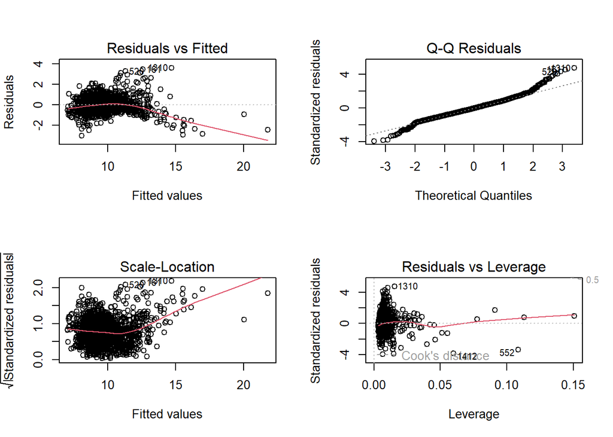

```r
par(mfrow=c(2,2))
plot(lm_bc)
```

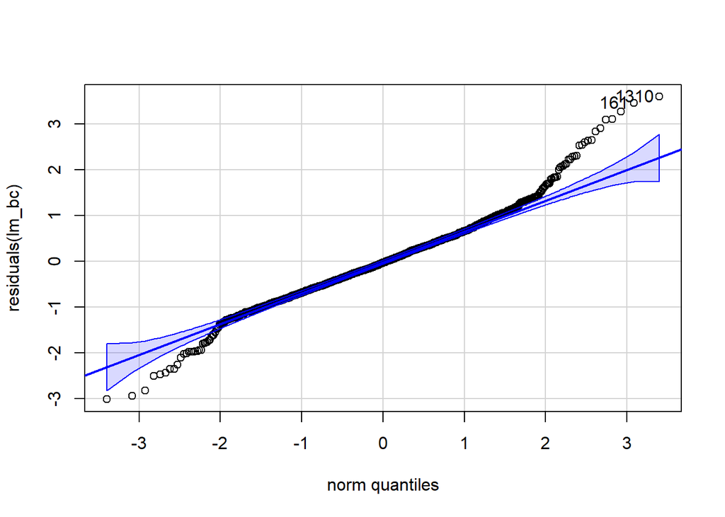

```
## [1] 1310  161
```

```r
qqPlot(residuals(lm_bc))
```

Residuals are approximately Normal in the center, but the tails deviate and a few outliers remain, so inference should be treated cautiously. That can make p-values and confidence intervals a bit optimistic.

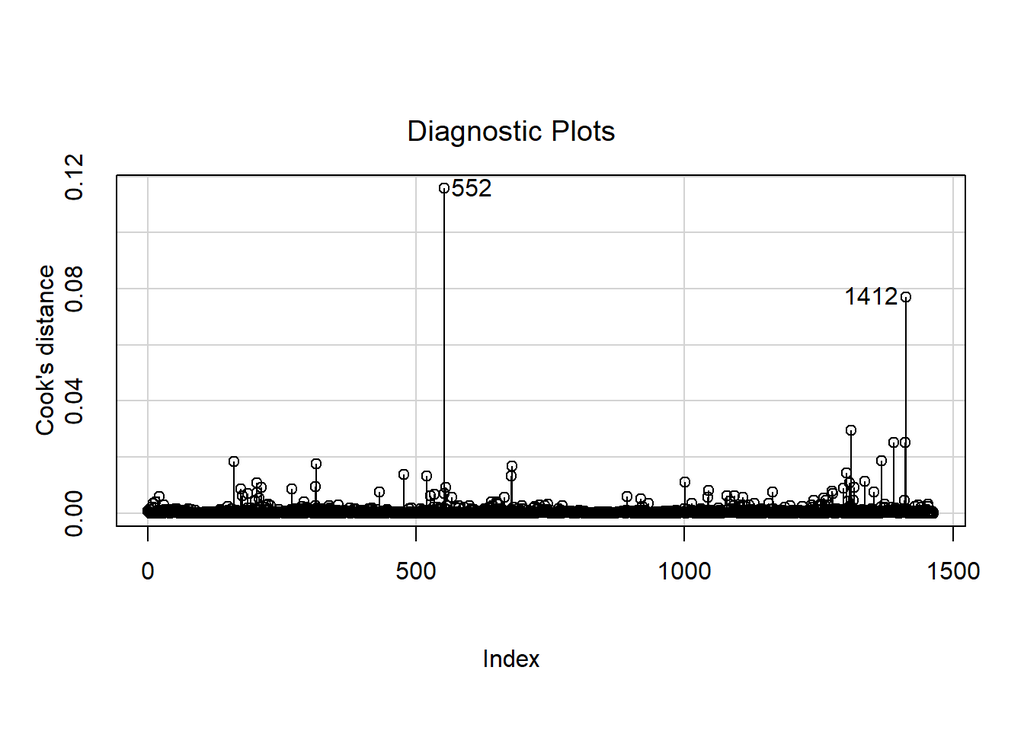

```r
influenceIndexPlot(lm_bc, vars = "Cook")
```

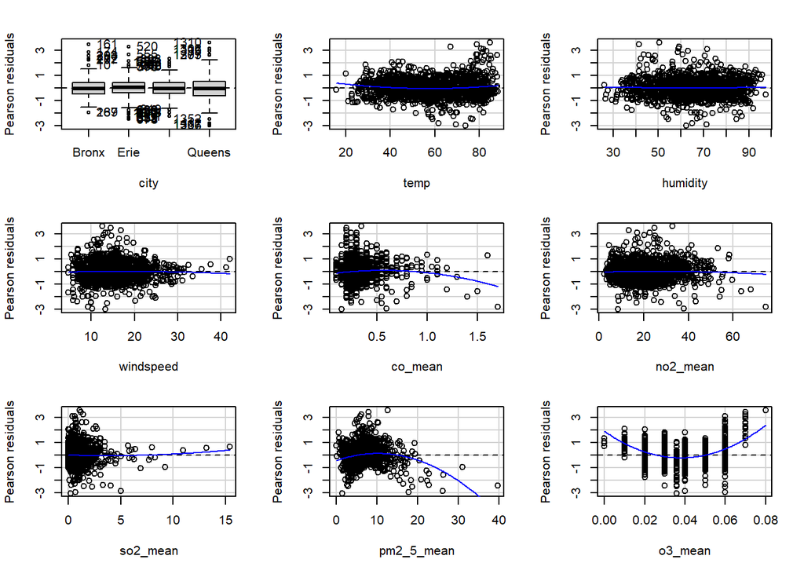

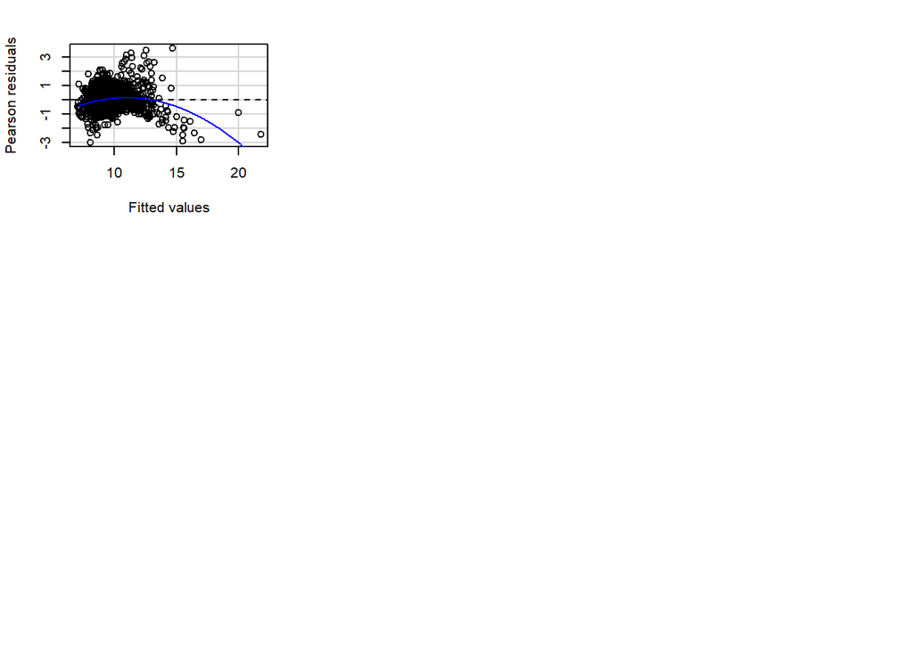

```
##            Test stat Pr(>|Test stat|)
## city
## temp          3.2262        0.0012824 **
## humidity      0.4102        0.6816953
## windspeed    -0.6790        0.4972316
## co_mean      -3.6480        0.0002736 ***
## no2_mean     -0.9016        0.3674196
## so2_mean      0.9850        0.3247744
## pm2_5_mean   -9.7592        < 2.2e-16 ***
## o3_mean      18.7926        < 2.2e-16 ***
## Tukey test  -10.5947        < 2.2e-16 ***
## ---
## Signif. codes:  0 '***' 0.001 '**' 0.01 '*' 0.05 '.' 0.1 ' ' 1
```

```r
residualPlots(lm_bc)
```

```r
pred_lm_bc <- predict(lm_bc, newdata = test_full)


# inverse Box-Cox (back to AQI)
tmp <- lambda * pred_lm_bc + 1
tmp[tmp < 0] <- NA                    # guard (should rarely happen)
pred_aqi_lm_bc <- tmp^(1/lambda)


rmse_lm_bc <- rmse(test_full$max_aqi, pred_aqi_lm_bc)
rmse_lm_bc
```

```
## [1] 6.880192
```

```r
resid_lm_bc <- test_full$max_aqi - pred_aqi_lm_bc
rse_lm_bc <- sqrt(sum(resid_lm_bc^2, na.rm = TRUE) / (sum(!is.na(resid_lm_bc)) - 1))
rse_lm_bc
```

```
## [1] 6.882543
```

## 4.1 Remove Influential Points from Box-Cox LM

```r
mf <- model.frame(lm_bc)

top_idx <- order(cd, decreasing=TRUE)[1:10]
top_idx
```

```
##  [1] 1310 1412  553  161 1302 1307 1411  204  520 1367
```

```r
# See the top rows used by the model:
mf[top_idx, ]
```

```
##          y_bc   city temp humidity windspeed co_mean no2_mean so2_mean
## 1310 18.28009 Queens 84.9     50.5      12.6    0.35    32.80      1.1
## 1412 14.16079 Queens 61.6     64.9       9.2    1.70    74.50      5.0
## 553  19.11493   Erie 75.3     58.7       7.9    0.55    21.45      3.1
## 161  16.02276  Bronx 78.9     41.4      14.5    0.20    24.75      1.2
## 1302 15.48140 Queens 82.0     71.5      13.8    0.25    22.80      0.6
## 1307 15.79319 Queens 88.1     45.6      16.5    0.30    26.15      0.8
## 1411 13.63048 Queens 62.9     52.3       6.1    1.40    54.05      2.0
## 204  15.16274  Bronx 82.3     70.4      10.6    0.30    27.20      0.7
## 520  14.58716   Erie 67.0     59.2      16.8    0.20    13.30      1.4
## 1367 12.59723 Queens 69.5     71.4      10.2    0.60    38.05      0.7
##      pm2_5_mean o3_mean
## 1310      12.60    0.08
## 1412      26.20    0.04
## 553       31.10    0.06
## 161        7.98    0.07
## 1302       7.90    0.07
## 1307      10.30    0.07
## 1411      22.33    0.04
## 204        8.25    0.07
## 520        6.13    0.07
## 1367      17.80    0.06
```

```r
# remove influential points

top5 <- order(cd, decreasing=TRUE)[1:5]
fit_drop_bc <- update(lm_bc, data = mf[-top5, ])  # refit on model-used data

summary(lm_bc)$coefficients[,1]
```

```
##   (Intercept)      cityErie    cityMonroe    cityQueens          temp
##  6.2936440611 -0.5715259297 -0.4096602450 -0.1088867189 -0.0080580465
##      humidity     windspeed       co_mean      no2_mean      so2_mean
##  0.0008848854 -0.0060140391 -0.8051959103  0.0058891137 -0.0058466245
##    pm2_5_mean       o3_mean
##  0.3817495098 56.2104441825
```

```r
summary(fit_drop_bc)$coefficients[,1]
```

```
##   (Intercept)      cityErie    cityMonroe    cityQueens          temp
##  6.2854258243 -0.5516857513 -0.3943687472 -0.1113795416 -0.0078762731
##      humidity     windspeed       co_mean      no2_mean      so2_mean
##  0.0008686637 -0.0052478366 -0.6385446523  0.0050145345 -0.0001076309
##    pm2_5_mean       o3_mean
##  0.3812400280 54.5190133058
```

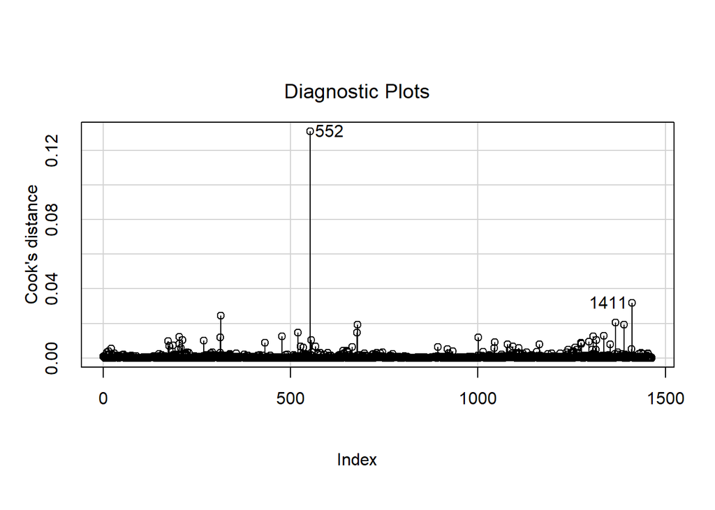

```r
influenceIndexPlot(fit_drop_bc, vars = "Cook")
```

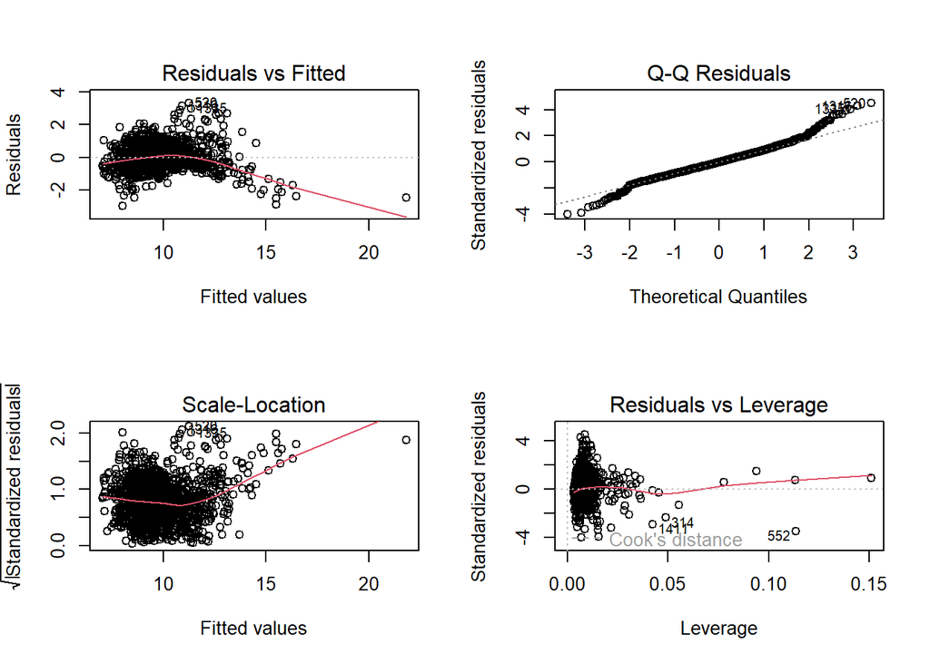

```r
par(mfrow=c(2,2))
plot(fit_drop_bc)
```

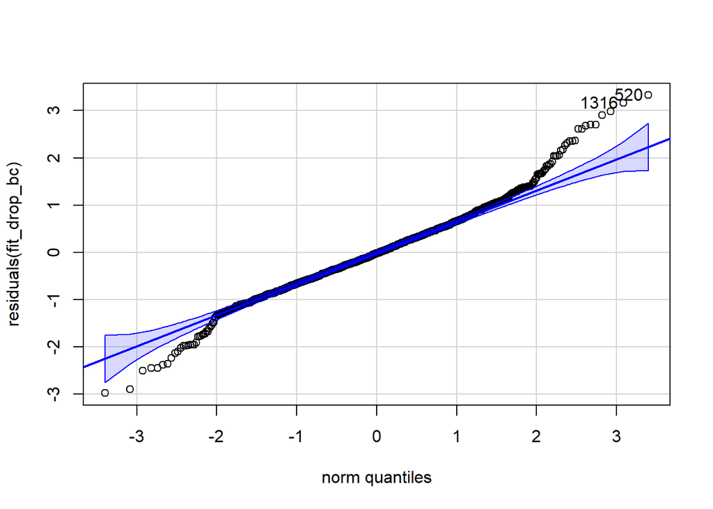

```
##  520 1316
##  519 1312
```

```r
qqPlot(residuals(fit_drop_bc))
```

```r
pred_fit_drop_bc <- predict(fit_drop_bc, newdata = test_full)


# inverse Box-Cox (back to AQI)
tmp <- lambda * pred_fit_drop_bc + 1
tmp[tmp < 0] <- NA                    # guard (should rarely happen)
pred_aqi_drop_bc <- tmp^(1/lambda)


rmse_fit_drop_bc <- rmse(test_full$max_aqi, pred_aqi_drop_bc)
rmse_fit_drop_bc
```

```
## [1] 6.847767
```

```r
resid_drop_bc <- test_full$max_aqi - pred_aqi_drop_bc
rse_drop_bc <- sqrt(sum(resid_drop_bc^2, na.rm = TRUE) / (sum(!is.na(resid_drop_bc)) - 1))
rse_drop_bc
```

```
## [1] 6.850107
```

# 5 LM with Month

```r
lm_month <- update(lm_full, . ~ . + month)
summary(lm_month)
```

```
##
## Call:
## lm(formula = max_aqi ~ city + temp + humidity + windspeed + co_mean +
##     no2_mean + so2_mean + pm2_5_mean + o3_mean + month, data = train_full)
##
## Residuals:
##     Min      1Q  Median      3Q     Max
## -19.586  -3.778  -0.486   2.927  53.537
##
## Coefficients:
##               Estimate Std. Error t value Pr(>|t|)
## (Intercept)  1.479e+01  1.674e+00   8.839  < 2e-16 ***
## cityErie    -4.069e+00  5.211e-01  -7.807 1.12e-14 ***
## cityMonroe  -4.304e+00  5.916e-01  -7.276 5.64e-13 ***
## cityQueens  -6.576e-01  4.713e-01  -1.395  0.16311
## temp         2.528e-02  2.599e-02   0.972  0.33101
## humidity     2.376e-04  1.369e-02   0.017  0.98616
## windspeed   -7.696e-02  3.623e-02  -2.124  0.03384 *
## co_mean     -4.638e+00  1.562e+00  -2.970  0.00303 **
## no2_mean     3.634e-02  2.449e-02   1.484  0.13806
## so2_mean    -1.073e-01  1.670e-01  -0.642  0.52082
## pm2_5_mean   3.095e+00  6.893e-02  44.901  < 2e-16 ***
## o3_mean      4.434e+02  1.897e+01  23.378  < 2e-16 ***
## month02     -2.760e+00  7.983e-01  -3.458  0.00056 ***
## month03     -4.695e+00  8.533e-01  -5.502 4.43e-08 ***
## month04     -3.934e+00  9.070e-01  -4.338 1.54e-05 ***
## month05     -3.985e+00  1.027e+00  -3.879  0.00011 ***
## month06     -1.978e+00  1.229e+00  -1.610  0.10768
## month07     -2.786e+00  1.313e+00  -2.121  0.03407 *
## month08     -5.094e+00  1.258e+00  -4.050 5.40e-05 ***
## month09     -7.764e+00  1.138e+00  -6.824 1.30e-11 ***
## month10     -6.536e+00  9.544e-01  -6.849 1.10e-11 ***
## month11     -4.331e+00  8.550e-01  -5.065 4.61e-07 ***
## month12     -2.388e-01  7.841e-01  -0.305  0.76073
## ---
## Signif. codes:  0 '***' 0.001 '**' 0.01 '*' 0.05 '.' 0.1 ' ' 1
##
## Residual standard error: 6.129 on 1441 degrees of freedom
## Multiple R-squared:  0.8141, Adjusted R-squared:  0.8113
## F-statistic: 286.9 on 22 and 1441 DF,  p-value: < 2.2e-16
```

After including the predictor **month**, the coefficient of **temp** has been dramatically decreased. Regarding **month** itself, most of the months are significant except month 6 and 12 and has negative coefficient of all the months. So, there are relationships among predictors.

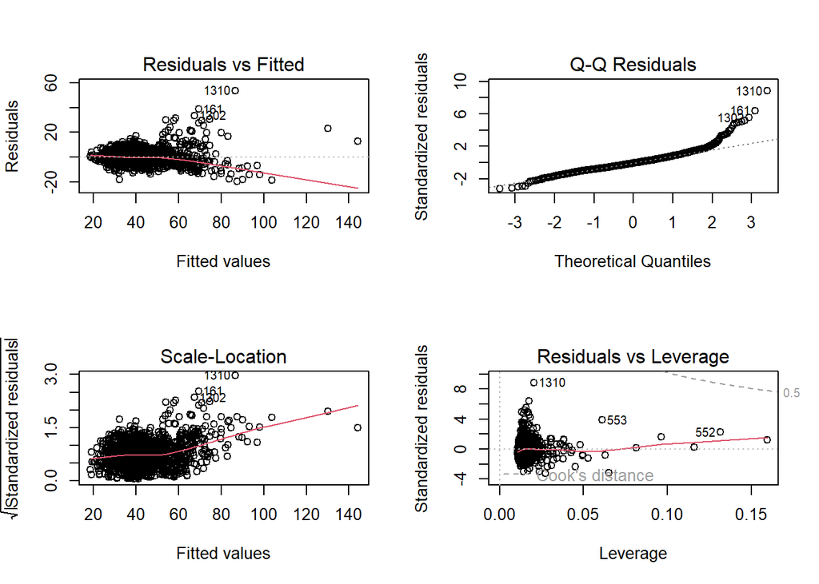

```r
par(mfrow=c(2,2))
plot(lm_month)
```

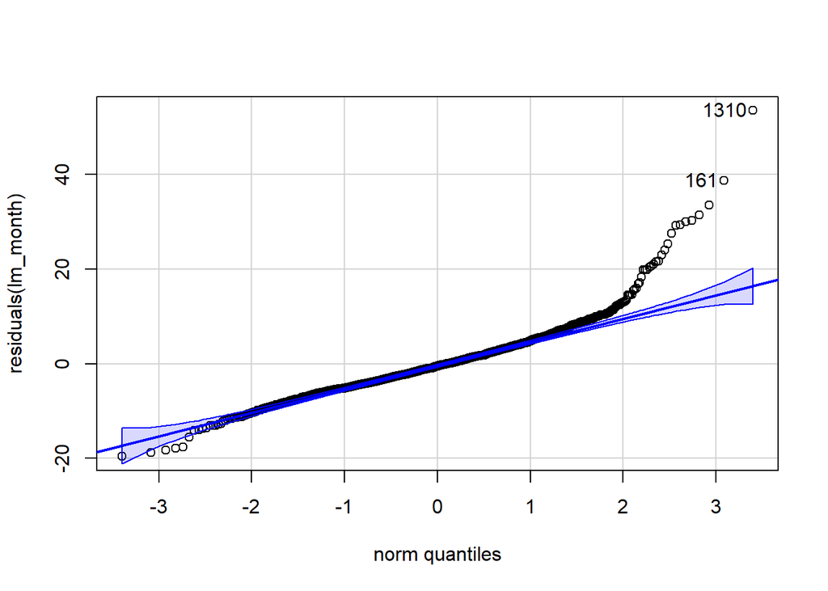

```
## [1] 1310  161
```

```r
qqPlot(residuals(lm_month))
```

The Q-Q plot shows some improvement kin the left tail.

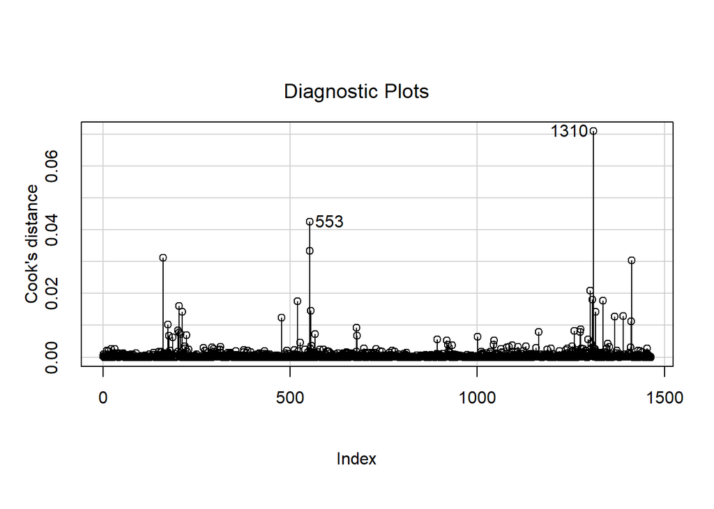

```r
influenceIndexPlot(lm_month, vars = "Cook")
```

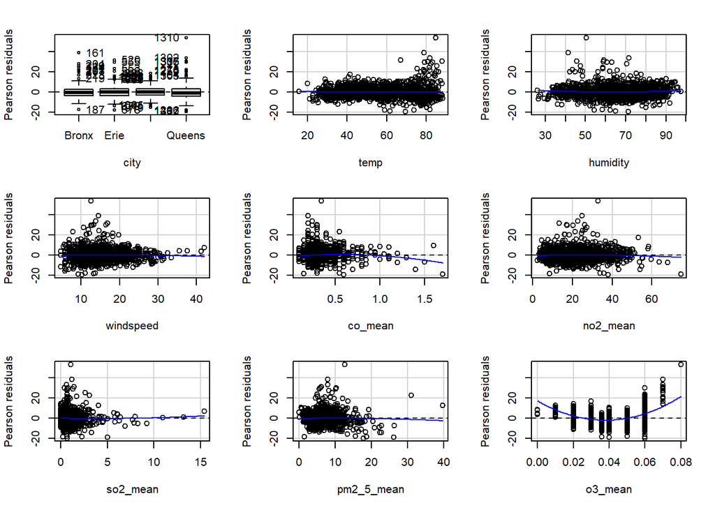

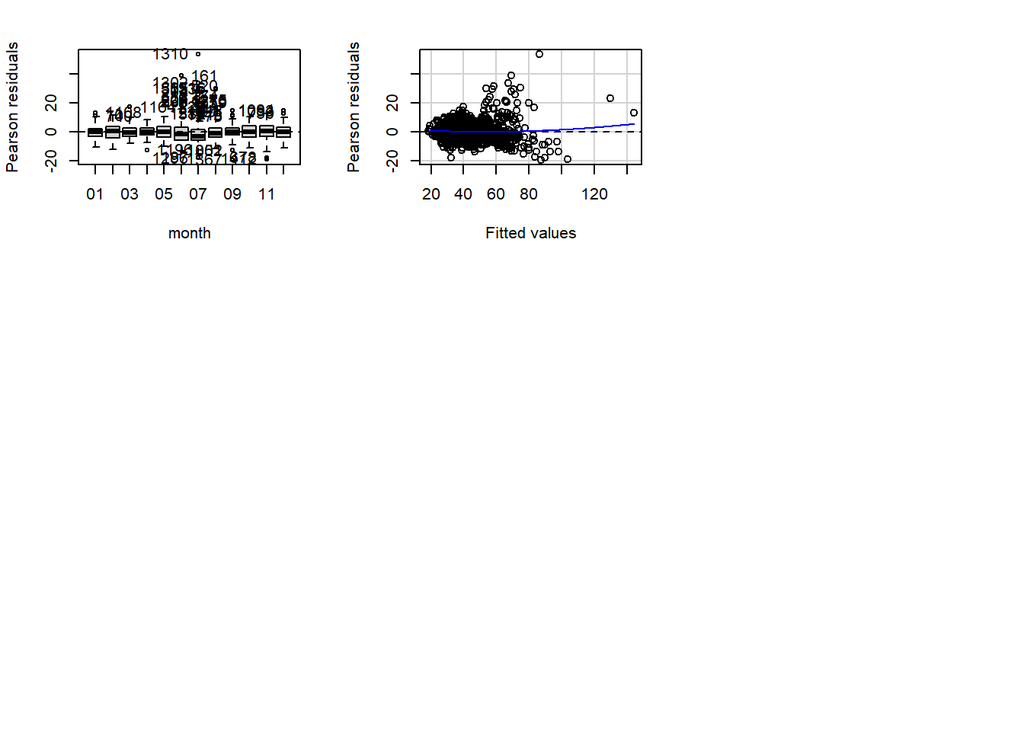

```
##            Test stat Pr(>|Test stat|)
## city
## temp          0.3532          0.72397
## humidity      1.8552          0.06378 .
## windspeed    -0.6488          0.51660
## co_mean      -2.9811          0.00292 **
## no2_mean     -1.1458          0.25207
## so2_mean      0.7282          0.46658
## pm2_5_mean   -0.6041          0.54584
## o3_mean      22.8577          < 2e-16 ***
## month
## Tukey test    1.6346          0.10213
## ---
## Signif. codes:  0 '***' 0.001 '**' 0.01 '*' 0.05 '.' 0.1 ' ' 1
```

```r
residualPlots(lm_month)
```

```r
pred_lm_month <- predict(lm_month, newdata = test_full)


rmse_lm_month  <- rmse(test_full$max_aqi, pred_lm_month)
rmse_lm_month
```

```
## [1] 6.323474
```

```r
resid_lm_month <- test_full$max_aqi - pred_lm_month
rse_lm_month <- sqrt(sum(resid_lm_month^2, na.rm = TRUE) / (sum(!is.na(resid_lm_month)) - 1))
rse_lm_month
```

```
## [1] 6.325635
```

After adding month the $R^2$ and the rmse are improved.

```r
c(rmse_lm_full= rmse_lm_full,
  rmse_fit_drop= rmse_fit_drop,
  rmse_lm_bc= rmse_lm_bc,
  rmse_fit_drop_bc= rmse_fit_drop_bc,
  rmse_lm_month= rmse_lm_month)
```

```
##     rmse_lm_full    rmse_fit_drop       rmse_lm_bc rmse_fit_drop_bc
##         6.564430         6.564430         6.880192         6.847767
##    rmse_lm_month
##         6.323474
```

```r
c(rse_lm = rse_lm,
  rse_fit_drop= rse_fit_drop,
  rse_lm_bc= rse_lm_bc,
  rse_drop_bc= rse_drop_bc,
  rse_lm_month= rse_lm_month)
```

```
##       rse_lm rse_fit_drop    rse_lm_bc  rse_drop_bc rse_lm_month
##     6.400673     6.504424     6.882543     6.850107     6.325635
```

Therefore, we are in a situation where the linearity assumption are not met, so we need to consider more robust model like **GAM** and/or **Interaction**.

Please go to the Part 4 - **GAM** to continue the analysis.